# Analysis of Multiple-Causes Scenario (Study 1a)

## 5.2 Bar Graphs Comparing Causal and Belief Inferences

The bar graphs below compares our model’s predictions on causal and belief inference against mean participants’ ratings (normalized). The error bars represent 95% confidence intervals. Participants’ ratings are shown on the top row of bar graphs, whereas our model’s predictions are illustrated on the bottom row.

```r
model_expectation$Hypothesis <- factor(model_expectation$Hypothesis, labels = c("Blue Box Only", "Orange Box Only","Both Boxes"), levels = c("Blue Box Only", "Orange Box Only","Both Boxes"))

model_expectation$Condition <- as.numeric(relabel(model_expectation$condition,
                                   from = c("emotion","no-emotion"),
                                   to = rev(c(1,2))
                                   ))

breaks <- unique(model_expectation$Condition)

#999999 - grey
#E69F00 - orange
#56B4E9 - light blue
#009E73 - green
#F0E442 - yellow
#0072B2 - dark blue
#D55E00 - red
#CC79A7 - pink

colorBlindGrey3   <- c("#0072B2", "#E69F00", "#009E73")

plot_model_expectation <- ggplot(model_expectation, aes(x = Condition, y = mean_pred, fill = Hypothesis)) +
  geom_bar(stat = "identity", position = "dodge") +
  geom_errorbar( data = model_expectation, aes(x = Condition,ymin=ci_lower_pred, ymax=ci_upper_pred, fill= Hypothesis), position=position_dodge(.9), width = .5, size = .5)+
  ylab("Likelihood Ratings")  +
  ylim(0,.7) +
  theme_bw() + xlab("")+
  scale_x_reverse(breaks=breaks, labels=c("Emotion", "No Emotion")) +
  scale_fill_manual(values = colorBlindGrey3) +
  theme(text = element_text(size = 32),
        axis.text.x = element_text(face = "bold", size = 32, hjust = 0.5),
        plot.title = element_text(face = "bold", size = 32, hjust = 0.5),
        legend.position="top")  +
  ggtitle("Belief Inference")
```

```r
model_cause$Hypothesis <- factor(model_cause$Hypothesis, labels = c("Blue Box Only", "Orange Box Only", "Both Boxes"), levels = c("Blue Box Only", "Orange Box Only", "Both Boxes"))

model_cause$Condition <- as.numeric(relabel(model_cause$condition,
                                   from = c("emotion","no-emotion"),
                                   to = rev(c(1,2))
                                   ))

breaks <- unique(model_cause$Condition)

#999999 - grey
#E69F00 - orange
#56B4E9 - light blue
#009E73 - green
#F0E442 - yellow
#0072B2 - dark blue
#D55E00 - red
#CC79A7 - pink

colorBlindGrey3   <- c("#0072B2", "#E69F00", "#009E73")

plot_model_cause <- ggplot(model_cause, aes(x = Condition, y = mean_pred, fill = Hypothesis)) +
  geom_bar(stat = "identity", position = "dodge") +
  geom_errorbar( data = model_cause, aes(x = Condition,ymin=ci_lower_pred, ymax=ci_upper_pred, fill= Hypothesis), position=position_dodge(.9), width = .5, size = .5)+
  ylab("Likelihood Ratings")  +
  ylim(0,.7) +
  theme_bw() + xlab("")+
  scale_x_reverse(breaks=breaks, labels=c( "Emotion","No Emotion")) +
  scale_fill_manual(values = colorBlindGrey3) +
  theme(text = element_text(size = 32),
        axis.text.x = element_text(face = "bold", size = 32, hjust = 0.5),
        plot.title = element_text(face = "bold", size = 32, hjust = 0.5),
        legend.position="top")  +
  ggtitle("Causal Inference")
```

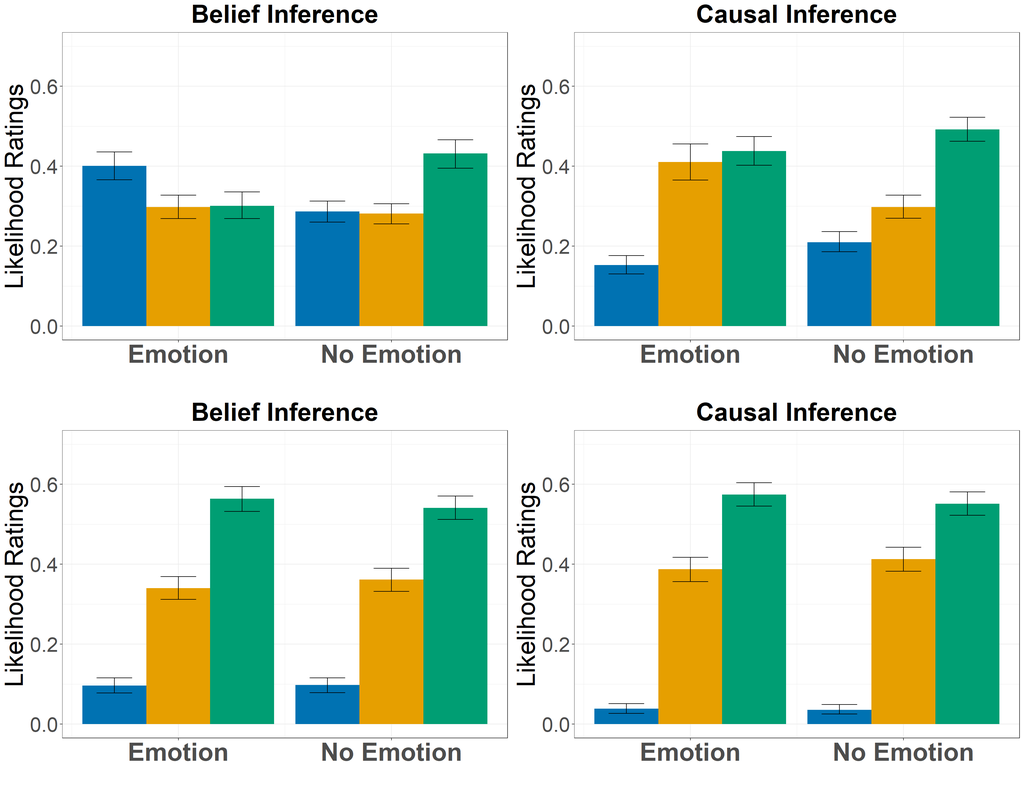

```r
# plotting causal inference and belief inference side by side

library(grid)
grid.newpage()
grid.draw(rbind(cbind(ggplotGrob(plot_human_expectation+theme(legend.position = "none")), ggplotGrob(plot_human_cause+theme(legend.position = "none")), size = "last"),
          cbind(ggplotGrob(plot_model_expectation+theme(legend.position = "none")), ggplotGrob(plot_model_cause+theme(legend.position = "none")), size = "last")))
```

```r
#500 x 1000
```

# 6 Hypothesis Testing

## 6.1 Belief Inferences

On belief inference, participants in the emotion condition were more likely to infer that the agent expected the blue box to turn on the bulb ($W = 3055.5, p < .001$) than participants in the no-emotion condition. This is consistent with our interpretation that participants in the emotion condition inferred that the agent expected that pushing the blue box would turn on the bulb, hence leading to his initial failed action.

```r
wilcox.test(expBlueNorm ~ condition, ecl_dat)
```

```
##
##  Wilcoxon rank sum test with continuity correction
##
## data:  expBlueNorm by condition
## W = 3055.5, p-value = 2.749e-06
## alternative hypothesis: true location shift is not equal to 0
```

Participants in the emotion condition were less likely to infer that the agent expected both boxes to turn on the bulb ($W = 1028.5, p < 0.001$) than participants in the no-emotion condition. Again, this is consistent with the interpretation that the participants inferred the agent’s intention to push box boxes from the beginning.

```r
wilcox.test(expBothNorm ~ condition, ecl_dat)
```

```
##
##  Wilcoxon rank sum test with continuity correction
##
## data:  expBothNorm by condition
## W = 1028.5, p-value = 8.945e-07
## alternative hypothesis: true location shift is not equal to 0
```

## 6.2 Causal Inferences

As expected, participants in the emotion condition were more likely to infer that the orange box turned on the bulb ($W = 2924, p < .001$), than participants in the no-emotion condition. We explained that participants in the emotion condition saw the agent’s first action (pushing blue box) as a mistake and hence, gave higher likelihood to the other box (orange box).

```r
wilcox.test(relationOrangeNorm  ~ condition, ecl_dat)
```

```
##
##  Wilcoxon rank sum test with continuity correction
##
## data:  relationOrangeNorm by condition
## W = 2924, p-value = 4.71e-05
## alternative hypothesis: true location shift is not equal to 0
```

Also, participants in the emotion condition were less likely to infer that pushing both boxes turned on the bulb ($W = 1507.0, p = .008$), than participants in the no-emotion condition. We explained that participants in the no-emotion condition assumed that both of the agent’s actions were intended and hence, inferred through the agent’s knowledge that both boxes were causally important to turn on the bulb. It should be noted that this hypothesis was still the modal hypothesis for participants across both conditions, despite their relative differences.

```r
wilcox.test(relationOrangeBlueNorm  ~ condition, ecl_dat)
```

```
##
##  Wilcoxon rank sum test with continuity correction
##
## data:  relationOrangeBlueNorm by condition
## W = 1507, p-value = 0.008159
## alternative hypothesis: true location shift is not equal to 0
```

## 6.3 Desire Inferences

With regards to desire inference, participants in the emotion condition were more likely to infer that the agent desired to turn on the light bulb ($W = 2527.5, p = .01$). However, from the descriptive means, we can see that participants in both conditions inferred strongly that the agent likely desired to turn on the bulb.

```r
wilcox.test(desire ~ condition, ecl_dat)
```

```
##
##  Wilcoxon rank sum test with continuity correction
##
## data:  desire by condition
## W = 2527.5, p-value = 0.01377
## alternative hypothesis: true location shift is not equal to 0
```

This table describes the mean (and SD in brackets) of the scaled desire ratings (between 0 and 1) for the emotion and no-emotion conditions.

```r
ecl_dat %>%
  group_by(condition) %>%
  summarise(
    desire = paste0(round(mean(desire, na.rm = T),2)," (",round(sd(desire, na.rm = T),2), ")")
  )
```

| condition | desire |
| --- | --- |
| emotion | 0.93 (0.14) |
| no-emotion | 0.89 (0.16) |

## 6.4 Knowledge Inferences

Finally, with regards to knowledge inference, participants in the emotion condition were less likely to infer that the agent was knowledgeable about how to turn on the bulb ($W= 1049.5, p < .001$) than participants in the no-emotion condition. This makes sense as the agent in the emotion condition signaled that he failed his initial action (pushing the blue box).

```r
wilcox.test(knowledge ~ condition, ecl_dat)
```

```
##
##  Wilcoxon rank sum test with continuity correction
##
## data:  knowledge by condition
## W = 1049.5, p-value = 1.201e-06
## alternative hypothesis: true location shift is not equal to 0
```

This table describes the mean (and SD in brackets) of the scaled knowledge ratings (between 0 and 1) for the emotion and no-emotion conditions.

```r
ecl_dat %>%
  group_by(condition) %>%
  summarise(
    knowledge = paste0(round(mean(knowledge, na.rm = T),2)," (",round(sd(knowledge, na.rm = T),2), ")")
  )
```

| condition | knowledge |
| --- | --- |
| emotion | 0.53 (0.25) |
| no-emotion | 0.75 (0.22) |